# Halloween Candy!

Anne Braae

31/07/2021

# Candy dataset

This data comes from the [candy hierarchy data](https://www.scq.ubc.ca/so-much-candy-data-seriously/) which was published annually around Halloween from 2014 to 2017. I used the 2015, 2016 and 2017 data sets. The raw data for 2014 is not available and so I did not include it.

The data was generated from an online survey of thousands of people from around the world, assessing their joy, despair or ambivalence to a wide range of Halloween candy and non-candy items.

There are a lot of free text columns and a range of auxiliary non-candy related questions in the survey. The main goal of this project was to gain experience cleaning and wrangling a real world data set. And oh how the halloween candy delivered on this! However this did mean that I didn’t have much time to explore and visualise the data. So now I will take a closer look.

## Assumptions

I made a number of assumptions when wrangling the data. Two of the more important are:

- I assumed that there was a data entry issue for the country column in 2016 and 2017. There were numbers entered into the country column where the corresponding age column was empty. I transferred these to the age column.
- I also assumed that the list of candy bars provided by the survey was exhaustive. I know this cannot be the case. I will assume that they include the most popular candy bars from the UK, US and Canada.

# Analysis

### Setup

Load libraries and cleaned data

```r
library(tidyverse)
library(here)
library(colorspace)
library(showtext)

clean_candy <- read_csv(here::here("clean_data/clean_candy.csv"))
```

```r
font_add_google(name = "Amatic SC", family = "amatic-sc")
showtext_auto()
scale <- 4.5 # scale is an adjustment for a 4k screen

# set theme
theme_set(theme_minimal())
theme <- theme(
  text = element_text(family = "amatic-sc", size = 5*scale),
  plot.title = element_text(size = 7*scale, hjust = 0.5),
  plot.subtitle = element_text(size = 4*scale, hjust = 0.5),
  plot.caption = element_text(size = 3.5*scale),
  legend.text = element_text(size = 2*scale))

theme_2 <- theme(
  text = element_text(family = "amatic-sc", size = 2*scale),
  plot.title = element_text(size = 7*scale, hjust = 0.5),
  plot.subtitle = element_text(size = 4*scale, hjust = 0.5),
  plot.caption = element_text(size = 3.5*scale),
  legend.text = element_text(size = 2*scale))
```

## Exploratory Data Analysis

What is the demographic of people completing the survey?

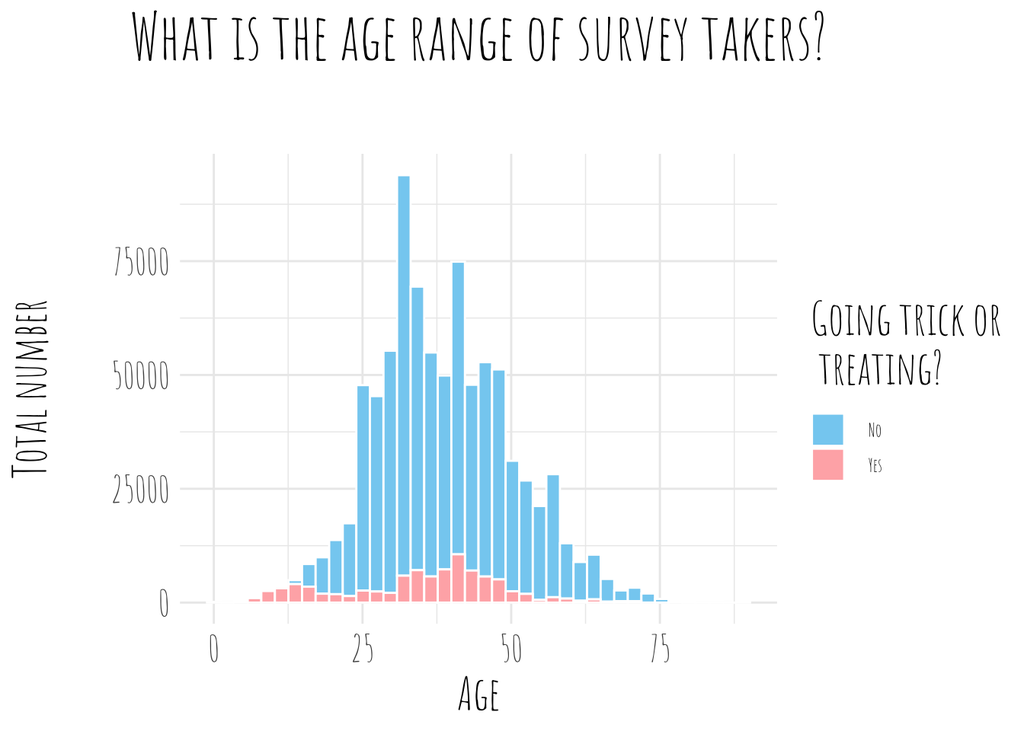

```r
clean_candy %>%
  filter(!is.na(going_trick_or_treat)) %>%
  ggplot() +
  aes(x = age, fill = going_trick_or_treat) +
  geom_histogram(col = "white", bins = 40)  +
  scale_fill_discrete_qualitative(
    palette = "set 3", nmax = 5, order = c(4, 1)) +
  theme +
  labs(
    title = "What is the age range of survey takers?\n",
    x = "Age",
    y = "Total number\n",
    fill = "Going trick or\n treating?"
  )
```

```r
#total number of ratings
clean_candy %>%
  summarise(rated = sum(!is.na(joy_induction)))
```

```
## # A tibble: 1 x 1
##    rated
##    <int>
## 1 772352
```

```r
#grouped by confectionery
clean_candy %>%
  group_by(confectionery) %>%
  summarise(rated = sum(!is.na(joy_induction)))
```

```
## # A tibble: 2 x 2
##   confectionery  rated
##   <lgl>          <int>
## 1 FALSE         165743
## 2 TRUE          606609
```

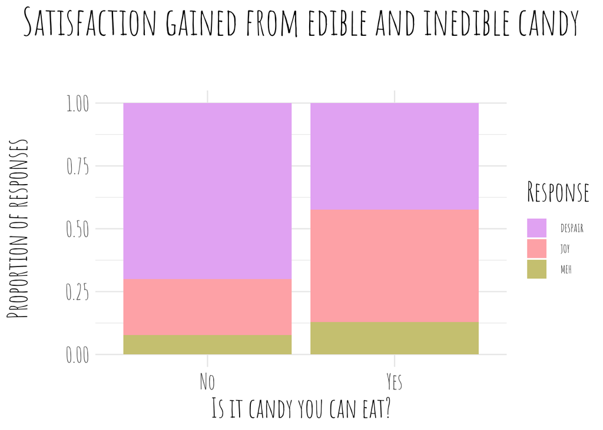

```r
clean_candy %>%
  filter(!is.na(joy_induction)) %>%
  mutate(confectionery = if_else(confectionery == TRUE, "Yes", "No")) %>%
  ggplot() +
  aes(x = confectionery, fill = joy_induction) +
  geom_bar(position = "fill") +
  scale_fill_discrete_qualitative(
    palette = "set 3", nmax = 5, order = c(5, 1, 2)) +
  theme +
  labs(
    title = "Satisfaction gained from edible and inedible candy\n",
    x = "Is it candy you can eat?",
    y = "Proportion of responses\n",
    fill = "Response"
  )
```

A total of 772352 candy ratings have been given over the three years. This is for all “candy” offered by the survey, including candy which is not a sweet. Breaking this down, 606609 ratings were given for candy you would find in a sweet shop and only 165743 ratings given for the inedible kind of candy.

count despair as -1, joy as +1 and meh as 0.

```r
rated_clean_candy <- clean_candy %>%
  mutate(
    rating = case_when(
      joy_induction == "DESPAIR" ~ as.numeric(-1),
      joy_induction == "JOY" ~ as.numeric(1),
      joy_induction == "MEH" ~ as.numeric(0),
      TRUE ~ NA_real_
    )
  )
```

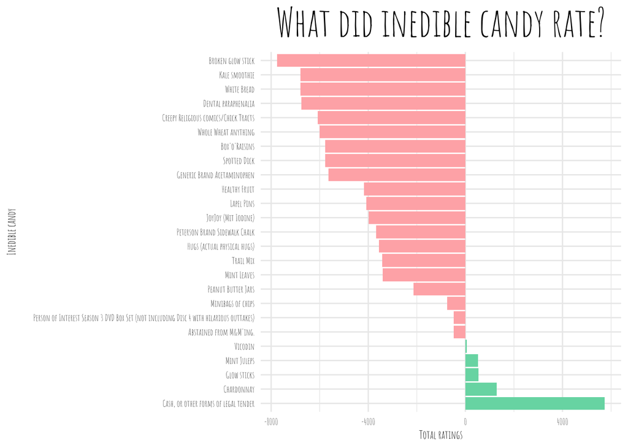

```r
rated_clean_candy %>%
  filter(confectionery == FALSE) %>%
  group_by(candy) %>%
  summarise(total_ratings = sum(rating, na.rm = TRUE)) %>%
  ggplot() +
  aes(x = total_ratings, y = reorder(candy, -total_ratings), fill =(total_ratings>0)) +
  geom_col() +
  scale_fill_discrete_qualitative(
    palette = "set 3", nmax = 5, order = c(1, 3)) +
  theme_2 +
  theme(legend.position = "none") +
  labs(
    title = "What did inedible candy rate?",
    x = "Total ratings",
    y = "Inedible candy\n"
  )
```

What was the most popular candy bar in each year?

```r
rated_clean_candy %>%
  filter(confectionery == TRUE) %>%
  select(year, candy, rating) %>%
  group_by(year, candy) %>%
  summarise(total_ratings = sum(rating, na.rm = TRUE)) %>%
  slice_max(total_ratings)
```

```
## # A tibble: 3 x 3
## # Groups:   year [3]
##    year candy                    total_ratings
##   <dbl> <chr>                            <dbl>
## 1  2015 Any full-sized candy bar          4603
## 2  2016 Any full-sized candy bar          1037
## 3  2017 Any full-sized candy bar          1542
```

For all three years, “Any full-sized candy bar” was the most popular candy. To find the most popular branded bar, I will filter this candy out from the data and rerun it.

```r
rated_clean_candy %>%
  filter(confectionery == TRUE,
         candy != "Any full-sized candy bar") %>%
  select(year, candy, rating) %>%
  group_by(year, candy) %>%
  summarise(total_ratings = sum(rating, na.rm = TRUE)) %>%
  slice_max(total_ratings)
```

```
## # A tibble: 3 x 3
## # Groups:   year [3]
##    year candy                      total_ratings
##   <dbl> <chr>                              <dbl>
## 1  2015 Reese’s Peanut Butter Cups          4375
## 2  2016 Kit Kat                              920
## 3  2017 Reese’s Peanut Butter Cups          1403
```

The most popular branded candy bar was Reese’s Peanut Butter Cups in 2015 and 2017 and Kit Kat in 2016.

What was the most popular candy bar by this rating for people in US, Canada, UK and all other countries?

```r
rated_clean_candy %>%
  filter(confectionery == TRUE,
         country != is.na(country)) %>%
  select(country, candy, rating) %>%
  group_by(country, candy) %>%
  summarise(total_ratings = sum(rating, na.rm = TRUE)) %>%
  slice_max(total_ratings)
```

```
## # A tibble: 5 x 3
## # Groups:   country [4]
##   country candy                    total_ratings
##   <chr>   <chr>                            <dbl>
## 1 canada  Any full-sized candy bar           253
## 2 other   Any full-sized candy bar            77
## 3 uk      Any full-sized candy bar            36
## 4 uk      Lindt Truffle                       36
## 5 us      Any full-sized candy bar          2173
```

The UK had a tie for the most popular candy bar, between “Any full-sized candy bar” and “Lindt Truffle” (both with a score of 36). All other countries scored “Any full-sized candy bar” as the best.

Again, to find the best scoring branded bar, filter out this chocolate.

```r
rated_clean_candy %>%
  filter(confectionery == TRUE,
         country != is.na(country),
         candy != "Any full-sized candy bar") %>%
  select(country, candy, rating) %>%
  group_by(country, candy) %>%
  summarise(total_ratings = sum(rating, na.rm = TRUE)) %>%
  slice_max(total_ratings)
```

```
## # A tibble: 4 x 3
## # Groups:   country [4]
##   country candy                      total_ratings
##   <chr>   <chr>                              <dbl>
## 1 canada  Kit Kat                              231
## 2 other   Kit Kat                               58
## 3 uk      Lindt Truffle                         36
## 4 us      Reese’s Peanut Butter Cups          1983
```

Now we can see a clear divide in the countries favourite candy bars. Canada and the rest of the world prefer Kit Kat with a rating of 231 and 58. The UK prefers Lindt Truffle with a score of 36 and the US prefers Reese’s Peanut Butter Cups with a score of 1983.

# Other interesting analyses or conclusions

What about M&M’s? Let’s have a look at what the most popular M&M types are for each country.

```r
rated_clean_candy %>%
  mutate(
    m_n_m = if_else(str_detect(candy, "M&M"), TRUE, FALSE)) %>%
  filter(confectionery == TRUE,
         country != is.na(country),
         candy != "Any full-sized candy bar",
         m_n_m == TRUE) %>%
  select(country, candy, rating) %>%
  group_by(country, candy) %>%
  summarise(total_ratings = sum(rating, na.rm = TRUE)) %>%
  slice_max(total_ratings)
```

```
## # A tibble: 4 x 3
## # Groups:   country [4]
##   country candy        total_ratings
##   <chr>   <chr>                <dbl>
## 1 canada  Regular M&Ms           172
## 2 other   Peanut M&M’s            53
## 3 uk      Regular M&Ms            27
## 4 us      Peanut M&M’s          1645
```

It’s a debate between regular and peanut M&M’s. Canada and the UK rate regular M&M’s the highest with ratings of 172 and 27 respectively. The US and the rest of the world rate Peanut M&M’s the highest with ratings of 1645 and 53.

It may be worth revisiting my earlier assumption that spliting the M&M’s and the Smarties were fine for this dataset. It would be interesting to see what all M&M’s combined score.